# Sparkify Project Workspace

This workspace contains a tiny subset (128MB) of the full dataset available (12GB). Feel free to use this workspace to build your project, or to explore a smaller subset with Spark before deploying your cluster on the cloud. Instructions for setting up your Spark cluster is included in the last lesson of the Extracurricular Spark Course content.

You can follow the steps below to guide your data analysis and model building portion of this project.

```python
!pip install --upgrade plotly
```

```python
# import libraries

from pyspark.sql import SparkSession, Window
from pyspark.sql.functions import avg, stddev, split, udf, isnull, isnan, first, col, format_number, rand
from pyspark.sql.functions import min as fmin
from pyspark.sql.functions import max as fmax
from pyspark.sql.types import IntegerType, FloatType

from pyspark.ml import Pipeline
from pyspark.ml.classification import LogisticRegression, GBTClassifier,RandomForestClassifier
from pyspark.ml.feature import StandardScaler, VectorAssembler
from pyspark.ml.evaluation import MulticlassClassificationEvaluator
from pyspark.mllib.evaluation import MulticlassMetrics
from pyspark.ml.tuning import CrossValidator, ParamGridBuilder

import plotly.express as px

import re
import copy
import time
import datetime
import numpy as np
import pandas as pd
import seaborn as sns
import matplotlib.pyplot as plt
from statsmodels.stats.proportion import proportions_ztest

%matplotlib inline
```

```python
# create a Spark session

spark = SparkSession \
    .builder \
    .appName("Sparkify") \
    .getOrCreate()
```

# Load and Clean Dataset

In this workspace, the mini-dataset file is `mini_sparkify_event_data.json`. Load and clean the dataset, checking for invalid or missing data - for example, records without userids or sessionids.

```python
df = spark.read.json('mini_sparkify_event_data.json')
df.show(1)
```

```
+--------------+---------+---------+------+-------------+--------+---------+-----+---------------+------+--------+-------------+---------+---------+------+-------------+--------------------+------+
|        artist|     auth|firstName|gender|itemInSession|lastName|   length|level|       location|method|    page| registration|sessionId|     song|status|           ts|           userAgent|userId|
+--------------+---------+---------+------+-------------+--------+---------+-----+---------------+------+--------+-------------+---------+---------+------+-------------+--------------------+------+
|Martha Tilston|Logged In|    Colin|     M|           50| Freeman|277.89016| paid|Bakersfield, CA|   PUT|NextSong|1538173362000|       29|Rockpools|   200|1538352117000|Mozilla/5.0 (Wind...|    30|
+--------------+---------+---------+------+-------------+--------+---------+-----+---------------+------+--------+-------------+---------+---------+------+-------------+--------------------+------+
only showing top 1 row
```

```python
df.printSchema()
```

```
root
 |-- artist: string (nullable = true)
 |-- auth: string (nullable = true)
 |-- firstName: string (nullable = true)
 |-- gender: string (nullable = true)
 |-- itemInSession: long (nullable = true)
 |-- lastName: string (nullable = true)
 |-- length: double (nullable = true)
 |-- level: string (nullable = true)
 |-- location: string (nullable = true)
 |-- method: string (nullable = true)
 |-- page: string (nullable = true)
 |-- registration: long (nullable = true)
 |-- sessionId: long (nullable = true)
 |-- song: string (nullable = true)
 |-- status: long (nullable = true)
 |-- ts: long (nullable = true)
 |-- userAgent: string (nullable = true)
 |-- userId: string (nullable = true)
```

```python
df.count()
```

```
286500
```

```python
#unique users
df.select("userId").dropDuplicates().count()
```

```
226
```

# Clean Data

```python
df.filter(isnull(df['userId'])).count()
```

```
0
```

```python
df.filter(df['userId']=='').count()
```

```
8346
```

```python
def missing_values(df, col):
    """
    input : dataframe, columns

    function to identify columns with missing values. identifies three cases of missing values
    1. Null
    2. NaN
    3. ""(empty string)
    """
    df=df.filter((isnan(df[col])) | (df[col].isNull()) | (df[col] == "")).count()
    return df
```

```python
for col in df.columns:
    missing_vals_count = missing_values(df, col)
    if missing_vals_count > 0:
        print("{}:{}".format(col, missing_vals_count))
```

```
artist:58392
firstName:8346
gender:8346
lastName:8346
length:58392
location:8346
registration:8346
song:58392
userAgent:8346
userId:8346
```

Convert the datetime format to the correct dtype

```python
# Create a user defined function for formating the timestamp
get_time = udf(lambda x: datetime.datetime.fromtimestamp(x / 1000.0).strftime("%Y-%m-%d %H:%M:%S"))

df = df.withColumn("time", get_time(df.ts))
```

```python
df.select(df.time).show(3)
```

```
+-------------------+
|               time|
+-------------------+
|2018-10-01 00:01:57|
|2018-10-01 00:03:00|
|2018-10-01 00:06:34|
+-------------------+
only showing top 3 rows
```

```python
#Add a weekday column
weekday = udf(lambda x: datetime.datetime.fromtimestamp(x/1000).strftime("%w"))
df = df.withColumn('weekday', weekday(df.ts))
```

```python
df_cleaned = df.filter((df['userId']!=''))
df_cleaned.count()
```

```
278154
```

# Exploratory Data Analysis

When you're working with the full dataset, perform EDA by loading a small subset of the data and doing basic manipulations within Spark. In this workspace, you are already provided a small subset of data you can explore.

```python
df_cleaned.printSchema()
```

```
root
 |-- artist: string (nullable = true)
 |-- auth: string (nullable = true)
 |-- firstName: string (nullable = true)
 |-- gender: string (nullable = true)
 |-- itemInSession: long (nullable = true)
 |-- lastName: string (nullable = true)
 |-- length: double (nullable = true)
 |-- level: string (nullable = true)
 |-- location: string (nullable = true)
 |-- method: string (nullable = true)
 |-- page: string (nullable = true)
 |-- registration: long (nullable = true)
 |-- sessionId: long (nullable = true)
 |-- song: string (nullable = true)
 |-- status: long (nullable = true)
 |-- ts: long (nullable = true)
 |-- userAgent: string (nullable = true)
 |-- userId: string (nullable = true)
 |-- time: string (nullable = true)
 |-- weekday: string (nullable = true)
```

```python
df_cleaned.describe('userId').show()
```

```
+-------+-----------------+
|summary|           userId|
+-------+-----------------+
|  count|           278154|
|   mean|59682.02278593872|
| stddev|109091.9499991047|
|    min|               10|
|    max|               99|
+-------+-----------------+
```

```python
df_cleaned.describe('sessionId').show()
```

```
+-------+------------------+
|summary|         sessionId|
+-------+------------------+
|  count|            278154|
|   mean|1042.5616241362698|
| stddev| 726.5010362219813|
|    min|                 1|
|    max|              2474|
+-------+------------------+
```

```python
df_cleaned.select("page").dropDuplicates().sort("page").show()
```

```
+--------------------+
|                page|
+--------------------+
|               About|
|          Add Friend|
|     Add to Playlist|
|              Cancel|
|Cancellation Conf...|
|           Downgrade|
|               Error|
|                Help|
|                Home|
|              Logout|
|            NextSong|
|         Roll Advert|
|       Save Settings|
|            Settings|
|    Submit Downgrade|
|      Submit Upgrade|
|         Thumbs Down|
|           Thumbs Up|
|             Upgrade|
+--------------------+
```

```python
#page events count
df_cleaned.groupby('page').count().orderBy('count', ascending=False).show()
```

```
+--------------------+------+
|                page| count|
+--------------------+------+
|            NextSong|228108|
|           Thumbs Up| 12551|
|                Home| 10082|
|     Add to Playlist|  6526|
|          Add Friend|  4277|
|         Roll Advert|  3933|
|              Logout|  3226|
|         Thumbs Down|  2546|
|           Downgrade|  2055|
|            Settings|  1514|
|                Help|  1454|
|             Upgrade|   499|
|               About|   495|
|       Save Settings|   310|
|               Error|   252|
|      Submit Upgrade|   159|
|    Submit Downgrade|    63|
|              Cancel|    52|
|Cancellation Conf...|    52|
+--------------------+------+
```

```python
user_location_count = df_cleaned.dropDuplicates(["userId"]).groupby(["location"]).count().sort('count', ascending=False).toPandas();
fig = px.bar(user_location_count, x='location', y='count',height = 600, width= 800,title="User location")
fig.show()
```

[interactive chart not shown]

```python
#user_location_count = df_cleaned.dropDuplicates(["userId"]).groupby(["location"]).count().sort('count', ascending=False).toPandas();
user_events = df_cleaned.groupby('page').count().orderBy('count', ascending=True).toPandas()
fig = px.bar(user_events, x='count', y='page',orientation='h',height = 400, width= 800,title="User activity")
fig.show()
```

[interactive chart not shown]

# Define Churn

Once you've done some preliminary analysis, create a column Churn to use as the label for your model. I suggest using the Cancellation Confirmation events to define your churn, which happen for both paid and free users. As a bonus task, you can also look into the Downgrade events.

```python
churn_event = udf(lambda x: 1 if x == "Cancellation Confirmation" else 0, IntegerType())

df_churn_defined = df_cleaned.withColumn("churned", churn_event(df_cleaned.page))

df_churn_defined.printSchema()
```

```
root
 |-- artist: string (nullable = true)
 |-- auth: string (nullable = true)
 |-- firstName: string (nullable = true)
 |-- gender: string (nullable = true)
 |-- itemInSession: long (nullable = true)
 |-- lastName: string (nullable = true)
 |-- length: double (nullable = true)
 |-- level: string (nullable = true)
 |-- location: string (nullable = true)
 |-- method: string (nullable = true)
 |-- page: string (nullable = true)
 |-- registration: long (nullable = true)
 |-- sessionId: long (nullable = true)
 |-- song: string (nullable = true)
 |-- status: long (nullable = true)
 |-- ts: long (nullable = true)
 |-- userAgent: string (nullable = true)
 |-- userId: string (nullable = true)
 |-- time: string (nullable = true)
 |-- weekday: string (nullable = true)
 |-- churned: integer (nullable = true)
```

# Explore Data

Once you've defined churn, perform some exploratory data analysis to observe the behavior for users who stayed vs users who churned. You can start by exploring aggregates on these two groups of users, observing how much of a specific action they experienced per a certain time unit or number of songs played

```python
df_churn_defined.select(["userId","gender","level","time","churned"]).show(5)
```

```
+------+------+-----+-------------------+-------+
|userId|gender|level|               time|churned|
+------+------+-----+-------------------+-------+
|    30|     M| paid|2018-10-01 00:01:57|      0|
|     9|     M| free|2018-10-01 00:03:00|      0|
|    30|     M| paid|2018-10-01 00:06:34|      0|
|     9|     M| free|2018-10-01 00:06:56|      0|
|    30|     M| paid|2018-10-01 00:11:16|      0|
+------+------+-----+-------------------+-------+
only showing top 5 rows
```

```python
df_churn_defined.groupby('churned').count().show()
```

```
+-------+------+
|churned| count|
+-------+------+
|      1|    52|
|      0|278102|
+-------+------+
```

```python
df_churn_defined.groupby('churned','level').count().toPandas()
```

|  | churned | level | count |
| --- | --- | --- | --- |
| 0 | 0 | free | 55700 |
| 1 | 0 | paid | 222402 |
| 2 | 1 | paid | 31 |
| 3 | 1 | free | 21 |

```python
level_df=df_churn_defined.groupby('churned','level').count().toPandas()
```

```python
level_df["churned"] = level_df["churned"].astype(str)
fig = px.bar(level_df, x='level', y='count',height = 400, width= 400, color='churned')
fig.show()
```

[interactive chart not shown]

```python
#df_cleaned.dropDuplicates(["userId"]).groupby(["location"]).count().sort('count', ascending=False).toPandas()
df_churned_subscribers = df_churn_defined.filter((df_churn_defined['churned']==1))
df_churned_gender = df_churned_subscribers.dropDuplicates(["userId"]).groupby(["gender"]).count().orderBy('count', ascending=False).toPandas();

fig = px.bar(df_churned_gender, x='gender', y='count',height = 400, width= 400)
fig.show()
```

[interactive chart not shown]

# Feature Engineering

Once you've familiarized yourself with the data, build out the features you find promising to train your model on. To work with the full dataset, you can follow the following steps.

- Write a script to extract the necessary features from the smaller subset of data
- Ensure that your script is scalable, using the best practices discussed in Lesson 3
- Try your script on the full data set, debugging your script if necessary

If you are working in the classroom workspace, you can just extract features based on the small subset of data contained here. Be sure to transfer over this work to the larger dataset when you work on your Spark cluster.

features to be looked at include

1. Gender
2. Subscription level
3. Downgrade events
4. User thumbs up
5. User thumbs down
6. user length

```python
gender_to_binary = udf(lambda x: 1 if x == "F" else 0, IntegerType())
Gender = df_cleaned.withColumn("Sex", gender_to_binary("gender"))

Gender = Gender.select('userId','Sex').groupBy('userId').sum().withColumnRenamed('sum(Sex)', 'Gender')
```

```python
Gender.show(5)
```

```
+------+------+
|userId|Gender|
+------+------+
|100010|   381|
|200002|     0|
|   125|     0|
|    51|     0|
|   124|  4825|
+------+------+
only showing top 5 rows
```

```python
#Downgrade event feature
subscription_flag = udf(lambda x: 1 if x == 'paid' else 0, IntegerType())
Subscription = df_cleaned.withColumn('Subscription_level', subscription_flag(df_cleaned.page))

#Add downgraded feature
Subscription = Subscription.select('userId', 'Subscription_level').sort('Subscription_level', ascending=False).dropDuplicates(subset=['userId'])
```

```python
Subscription.show(5)
```

```
+------+------------------+
|userId|Subscription_level|
+------+------------------+
|100010|                 0|
|200002|                 0|
|   125|                 0|
|    51|                 0|
|   124|                 0|
+------+------------------+
only showing top 5 rows
```

```python
#Downgrade event feature
Downgraded_event = udf(lambda x: 1 if x == 'Submit Downgrade' else 0, IntegerType())
df_cleaned = df_cleaned.withColumn('Subscription_downgrade', Downgraded_event(df_churn_defined.page))

#Add downgraded feature
downgrade = df_cleaned.select('userId', 'Subscription_downgrade').sort('Subscription_downgrade', ascending=False).dropDuplicates(subset=['userId'])
```

```python
downgrade.show(5)
```

```
+------+----------------------+
|userId|Subscription_downgrade|
+------+----------------------+
|100010|                     0|
|200002|                     0|
|   125|                     0|
|    51|                     0|
|   124|                     0|
+------+----------------------+
only showing top 5 rows
```

```python
positive_rating = df_cleaned.filter(df_cleaned["page"] == 'Thumbs Up').groupby('userId').count().withColumnRenamed("count", "Thumbs_up")
positive_rating.show(5)
```

```
+------+---------+
|userId|Thumbs_up|
+------+---------+
|100010|       17|
|200002|       21|
|    51|      100|
|   124|      171|
|     7|        7|
+------+---------+
only showing top 5 rows
```

```python
negative_rating = df_cleaned.filter(df_churn_defined["page"] == 'Thumbs Down').groupby('userId').count().withColumnRenamed("count", "Thumbs_down")
negative_rating.show(5)
```

```
+------+-----------+
|userId|Thumbs_down|
+------+-----------+
|100010|          5|
|200002|          6|
|    51|         21|
|   124|         41|
|     7|          1|
+------+-----------+
only showing top 5 rows
```

```python
#User listening time
listening_time =df_cleaned.select('userId','length').groupBy('userId').sum().withColumnRenamed('sum(length)', 'time_spent')
listening_time.show(5)
```

```
+------+------------------+
|userId|        time_spent|
+------+------------------+
|100010| 66940.89735000003|
|200002| 94008.87593999993|
|   125|2089.1131000000005|
|    51| 523275.8428000004|
|   124|1012312.0927899999|
+------+------------------+
only showing top 5 rows
```

```python
df = df_churn_defined.groupby('userId').max("churned").withColumnRenamed("max(churned)", "churn")

final_df =df.join(Gender,on='userId', how='outer') \
    .join(Subscription,on='userId', how='outer') \
    .join(downgrade,on='userId', how='outer') \
    .join(positive_rating,on='userId', how='outer') \
    .join(negative_rating,on='userId', how='outer') \
    .join(listening_time,on='userId', how='outer')\
    .fillna(0)
```

```python
final_df.printSchema()
```

```
root
 |-- userId: string (nullable = true)
 |-- churn: integer (nullable = true)
 |-- Gender: long (nullable = true)
 |-- Subscription_level: integer (nullable = true)
 |-- Subscription_downgrade: integer (nullable = true)
 |-- Thumbs_up: long (nullable = true)
 |-- Thumbs_down: long (nullable = true)
 |-- time_spent: double (nullable = false)
```

# Modeling

Split the full dataset into train, test, and validation sets. Test out several of the machine learning methods you learned. Evaluate the accuracy of the various models, tuning parameters as necessary. Determine your winning model based on test accuracy and report results on the validation set. Since the churned users are a fairly small subset, I suggest using F1 score as the metric to optimize.

```python
#Split the Data into Train and Test Datasets
train, test = final_df.randomSplit([0.75, 0.25], seed=0)
```

```python
# create assembler and scaler for our pipeline; we choose F1 score for evaluator as suggested
Assembler = VectorAssembler(inputCols=['Gender','Subscription_level','Subscription_downgrade',
                                         'Thumbs_up','Thumbs_down','time_spent'],
                              outputCol="features")
scaler = StandardScaler(inputCol='features', outputCol='scaled')
evaluator = MulticlassClassificationEvaluator(labelCol='churn', predictionCol='prediction', metricName='f1')
scores = []
```

# Logistic regression

```python
# create pipeline with logistic regression classifier, using default settings, train model and measure score against test
logistic_regression_classifier = LogisticRegression(featuresCol='scaled', labelCol='churn')
pipeline = Pipeline(stages=[Assembler, scaler, logistic_regression_classifier])
model = pipeline.fit(train)
preds = model.transform(test)
scores.append(['Logistic Regression', evaluator.evaluate(preds)])
```

# Random Forest

```python
# and random forest
random_forest_classifier = RandomForestClassifier(featuresCol='scaled', labelCol='churn')
pipeline = Pipeline(stages=[Assembler, scaler, random_forest_classifier])
model = pipeline.fit(train)
preds = model.transform(test)
scores.append(['Random Forest', evaluator.evaluate(preds)])
```

# Gradient boosted classifier

```python
gbt_classifier = GBTClassifier(featuresCol='scaled', labelCol='churn')
pipeline = Pipeline(stages=[Assembler, scaler, gbt_classifier])
model = pipeline.fit(train)
preds = model.transform(test)
scores.append(['GBT', evaluator.evaluate(preds)])
```

```python
scores_df = pd.DataFrame(scores,columns=['Classifier', 'F1 Score'])
scores_df.head()
```

|  | Classifier | F1 Score |
| --- | --- | --- |
| 0 | Logistic Regression | 0.749512 |
| 1 | Random Forest | 0.809483 |
| 2 | GBT | 0.773488 |

```python
# we can now plot scores for all models and compare them
fig = px.bar(scores_df, x='Classifier', y='F1 Score',height = 400, width= 600,color ='Classifier')
fig.update_yaxes(range = [0,1])
fig.show()
```

[interactive chart not shown]

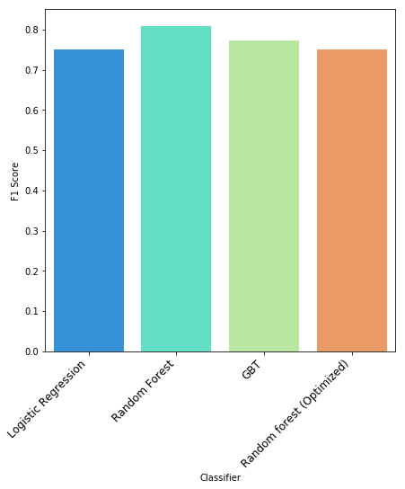

```python
pipeline = Pipeline(stages=[Assembler, scaler, random_forest_classifier])

param_grid = ParamGridBuilder()\
.addGrid(random_forest_classifier.maxDepth, [3,5,10])\
.build()

cv = CrossValidator(estimator=pipeline,
                    estimatorParamMaps = param_grid,
                    evaluator = evaluator,
                    numFolds=4)
model = cv.fit(train)
preds = model.transform(test)
scores.append(['Random forest (Optimized)', evaluator.evaluate(preds)])
scores_df = pd.DataFrame(scores,columns=['Classifier', 'F1 Score'])
plt.figure(figsize=(7,7))
chart = sns.barplot(x='Classifier',y='F1 Score',data=scores_df,palette='rainbow')
chart.set_xticklabels(
    chart.get_xticklabels(),
    rotation=45,
    horizontalalignment='right',
    fontsize='large'
)
chart.set_yticks(np.arange(0,0.81,0.1))
plt.show()
```